# Advanced Topics in Data Science 2018/2019: Practical Assignment - Movies Recommendation

Group 5: Catarina Alves, Francisca Conrado, Ofelia Godinho

May 2019

# Introduction

On a daily basis, we are surrounded by various recommendations systems, which are imposed on us without our awareness. In general, recommendation systems are computational approaches that incorporate algorithms that aim to learn potentially useful or pleasant products to the user (1). Thus, the learning events may be based on several situations, such as more frequent events or similarity between users or products.

The use of recommendation systems has been increasing exponentially with the growth of massive use of the Internet (2). The recommendation of web pages is one of several applications of these systems, where the user visits a web page and is suggested a hyperlink to another site that may be of his liking. Another example is the online recommendation of films and series (1), such as the Rotten Tomatoes review site which, through the scores given to a movie or film, performs recommendations that will please a certain user or the general public (3). Spotify or Apple Music music recommendations, as well as suggestions for connections/friends on social networks such as LinkedIn or Facebook, are other examples.

The aim of this project is to, through three different approaches, Popularity, Rules of Association and Collaborative Filter, predict ratings and thus obtain recommendations starting from the data set rotten tomatoes available and using different information for analysis, namely binary and non-binary.

# Problem definition

The ultimate goal is to being able to make good movies recommendations from the information available on two data sets from Rotten Tomatoes. To do so, it is necessary to process the data so that it is present on a useful way and it can be used to create the various models. In order to obtain the most effective recommendation model for this project, it is essential to explore different parameters and types of recommendation systems to obtain the best results.

# Task 1 - Exploratory data analysis and pre-processing

## Data import

First, we begin by importing the data. In order to avoid that our code relies on an absolute path, as requested, we decided to create a temporary path and download the zip file into that path. Afterwards, we can extract the target tsv files, before eliminating the temporary path and zip file.

In this assignment, the data set includes two files:

- *movie_info.tsv* : a file that provide additional information on the movies reviewed by the critics;
- *reviews.tsv*: a file with information regarding each review.

We will first pre-process each file individually.

## Pre-processing

### Reviews

The reviews.tsv file contains a data frame with 8 variables and 54432 observations.

In this data set, each observation represents a review by a specific critic. The variables available are:

- *id*: id of the movie reviewed by the critics;
- *review*: the review written by each critic for the movie in question;
- *rating*: rating given by the critic; can be displayed in different scales;
- *fresh*: a binary metric related to the Tomatometer score; if a movie has a rating above 60% it displays the “fresh” status; it displays its “rotten” status otherwise;
- *critic*: name of the critic;
- *top_critic*: binary classification by activity relevance of critics
- *publisher*: what magazine, journal, website, etc., the review was published on;
- *date*: date of publication of the review;

We started by analyzing the presence of NA’s in the data-set.

Table 1: NA analysis among variables.

|  | Valid | NA |
| --- | --- | --- |
| rating | 40915 | 13517 |
| review | 48869 | 5563 |
| critic | 51710 | 2722 |
| publisher | 54123 | 309 |
| id | 54432 | 0 |
| fresh | 54432 | 0 |
| top_critic | 54432 | 0 |
| date | 54432 | 0 |

Afterwards, we analyse the remaining variables and noticed that the *date* variable is set as character. To allow its use, we converted this into a date format with the package *lubridate*. Besides that, we also derived two new variables from this: Year and Month.

Another issue was the rating scales. The variable rating contains two types of rating scales, with different versions:

- Numeric scales:
  - from 0 to 2
  - from 0 to 4
  - from 0 to 5
  - from 0 to 6
  - from 0 to 8
  - from 0 to 10
- Alphabetic scale:
  - from A+ to F-

To allow it use, all the different scales were converted to the scale from 0 to 5 which we discover to be the most frequent. Furthermore, numeric scales also presented different lexical representations since some had the “/” as separator (as in 2/5) while a scale from 0 to 10 did not. To deal with this, we first started to convert the numeric rating values where the character “/” was not found. Next, all the numeric ratings where the character “/” was found were converted, according to the value on the right hand side of the separator. Finally, the alphabetic scale was converted considering that the each letter representation corresponds to a value within a scale from 1 (F-) to 18 (A+).

Along the way we came across a couple errors that lead to the elimination of the correspondent entry since we were not able to correct them or understand it meaning. For instance, two ratings of T and N were found, and also numeric ratings of “3/2” and “3 2/4”.

Afterwards, all ratings were converted to a numeric type so they can be used for posterior statistical analysis.

Firstly, we analysed the resulting distributing by plotting the movie count per rating. We can see in Figure 1 that rating distribution doesn’t seem to follow any particular pattern.

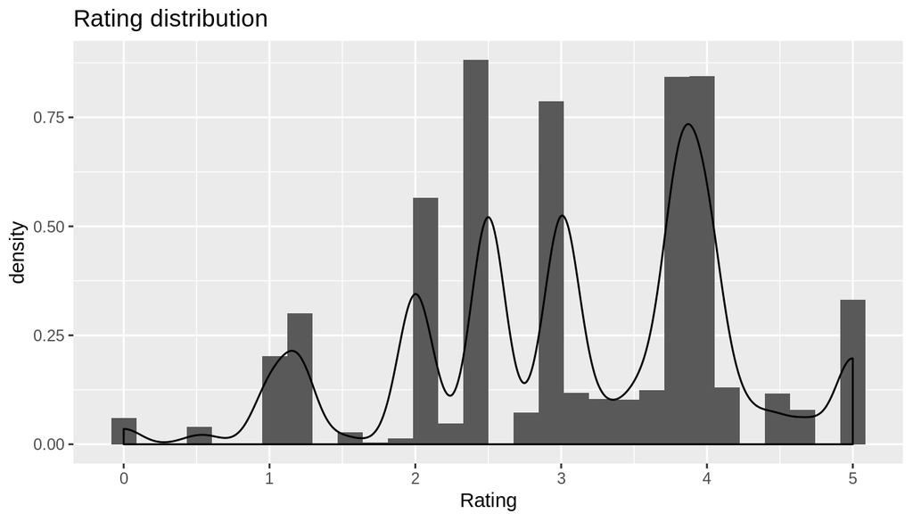

Figure 1: Rating distribution

Next we decided to analyse the distribution of reviews per year. As we can see in Figure 2, most reviews are concentrated around 2000 to 2015.On the right side of Figure 2, we can also see that the mean rating of reviews per year is not a steady variable and thus should be taken into consideration.

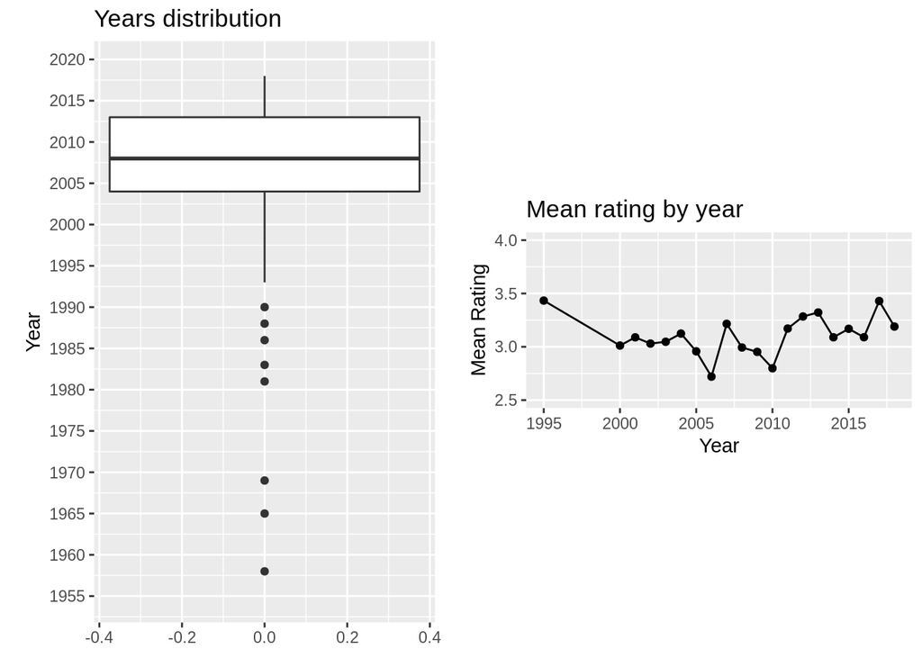

Figure 2: Years visual analysis

### Movie Info

The movie_info.tsv file contains a data frame with 12 variables and 1560 observations.

In this case, each observation represents a movie, and the variables different attributes from the movie. The variables available are:

- *id*: id of the movie; matches the one in the review data frame;
- *synopsis*: description of the movie;
- *rating*: a rating scale regarding the film’s suitability for certain audiences based on its content;
- *genre*: movie category;
- *director*: director(s) of the movie;
- *writer*: writer(s) of the movie;
- *theater_date*: when the movie premiered in movie theaters;
- *DVD_date*: when the movie was released as a DVD;
- *currency*: currency in which box office results are shown;
- *box_office*: the amount of money obtained by sales of tickets to the movie;
- *run-time*: length of the movie;
- *studio*: studio responsible for the movie;

After the processing of reviews data frame, some movies present in *movie_info* did not have any reviews. So it was important to first select the remaining movies ID. We will also analyse the number of reviews per movie and the mean rating of each movie.

We start of once again by analyzing the presence of missing values in this data-frame.

Table 2: NA analysis among variables

|  | Valid | NA |
| --- | --- | --- |
| currency | 299 | 756 |
| box_office | 299 | 756 |
| studio | 412 | 643 |
| writer | 839 | 216 |
| director | 946 | 109 |
| theater_date | 951 | 104 |
| dvd_date | 951 | 104 |
| runtime | 1045 | 10 |
| synopsis | 1046 | 9 |
| genre | 1053 | 2 |
| rating | 1054 | 1 |
| id | 1055 | 0 |
| Mean_rating | 1055 | 0 |
| Count | 1055 | 0 |

From results in table 2, we can conclude that too many movies are lacking values for the variables *currency*, *box_office* and *studio*. Because of this, we will discard these variables from further analysis.

The second issue we observe in this data frame is that *theater_date*, *DVD_date* are not in the class date but as characters. Once again we resort to package *lubridate* to process this information. We also extracted Year_theater from *theater_date*, and Year_DVD from *DVD_date*;

On the other hand, the variable *runtime* is displayed as character, but should be numeric. It also includes extra characters (“minutes”) that should be removed.

Finally, the variables *genre*, *director* and *writer* can contain more than one name per observation, thus it should be split as different individuals to allow a correct analysis.

The separation allowed us to obtain 21 individual genres, which are displayed on Figure 3 along with each movie count.

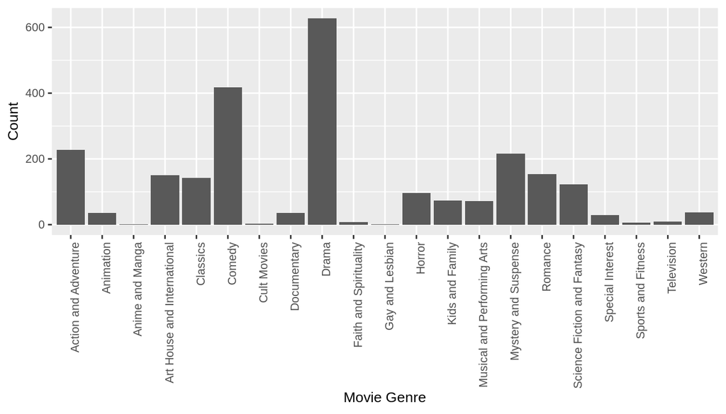

Figure 3: Movie count per genre

.

A similar analysis was performed for movie’s director (Figure 4). We represented only the directors with a minimum of three movies to reduce the variable dimension and end up with a total of 24 individuals. In general, the movie count is quite low, with exception for Steven Spielberg and Clint Eastwood who stand out from the remaining.

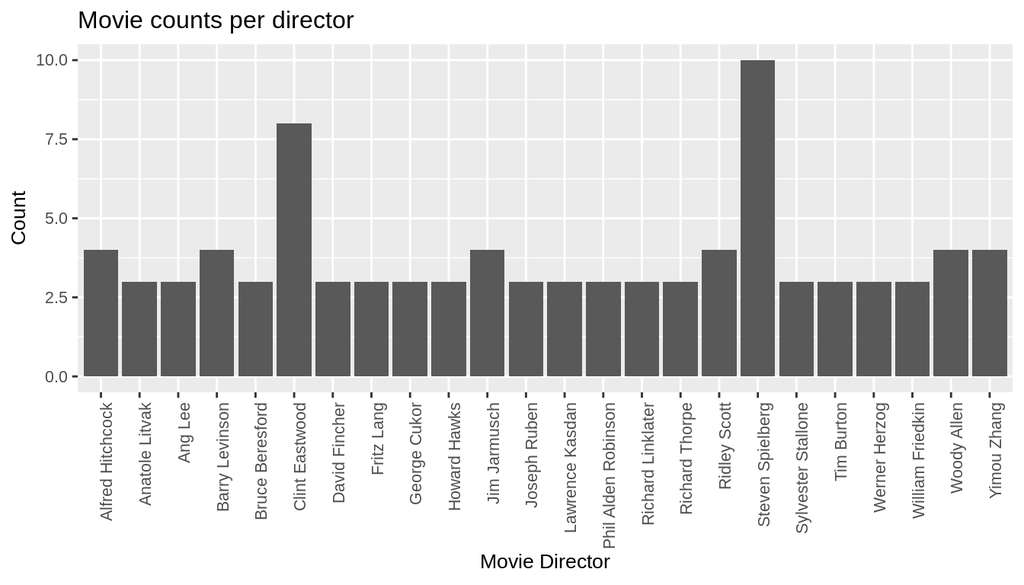

Figure 4: Movie count per director. Here are represented only the directors with at least three movies.

Once more, a similar analysis was performed for movie’s writers (Figure 5). We represented only the writers with at least three movies, ending up with a total of 21 individuals.

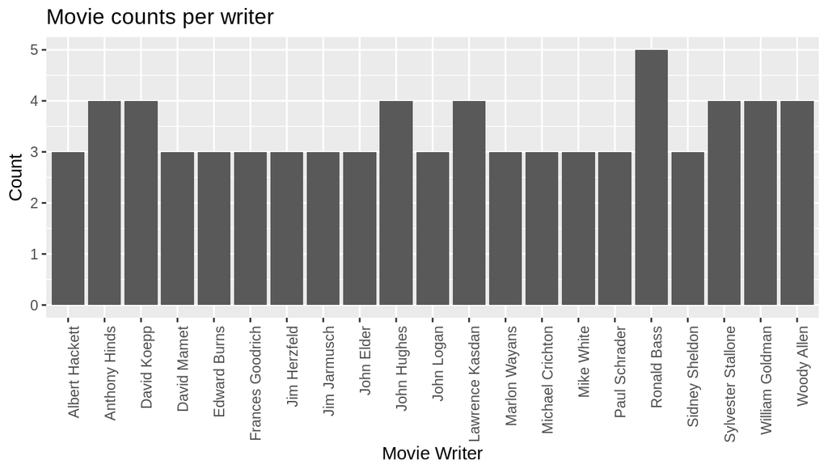

Figure 5: Movie count per writer. Here are represented only the writers with at least three movies.

### Visual Analysis

To evaluate the effect of different variables on the the rating of a review, the mean rating by different grouped variables was assessed.

As we can see on Figure 6, the rating of a movie influences the rating of its review, with PG-13 having a lower mean rating than all other ratings.

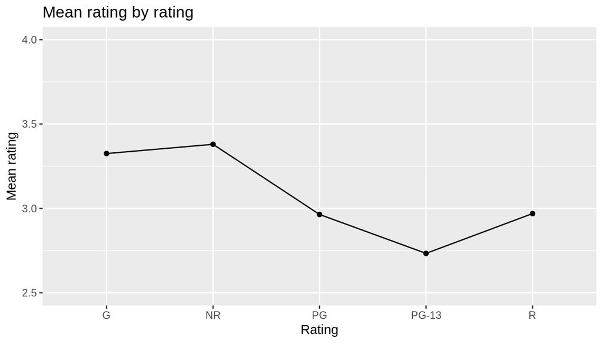

Figure 6: Mean rating of reviews per movie rating

Furthermore, as we can can see o Figure 7, the run-time of the movie also influences the mean rating, with longer movies having better ratings.

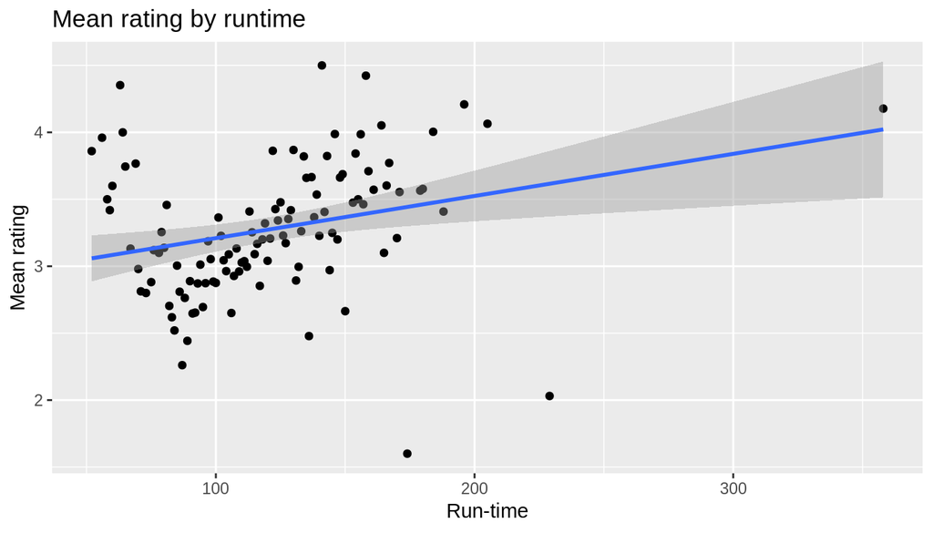

Figure 7: Mean rating of reviews per movie runtime.

With regard to movie genre, Figure 8 shows that mean rating does not have a consistent behavior although we believe that it is highly influenced by the great differences in movies counts. Indeed, the movies with fewer counts are the ones that exhibit the most dissimilar ratings.

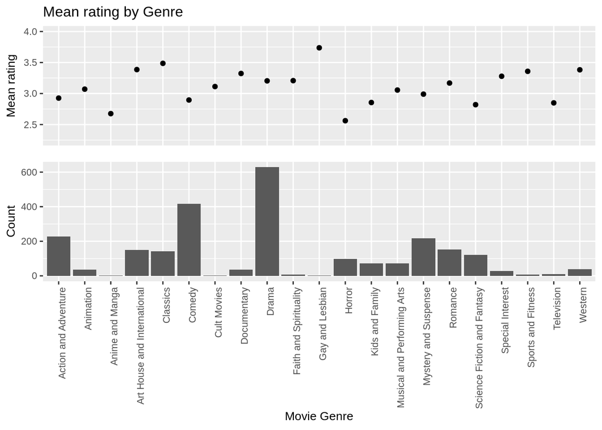

Figure 8: Mean rating by movie genre. Top graphic represents mean rating per genre, while bottom graphic represents the movie count per genre.

On the other hand, most directors have less then 5 movies and yet we can still observe some differences in mean rating values (figure 9).

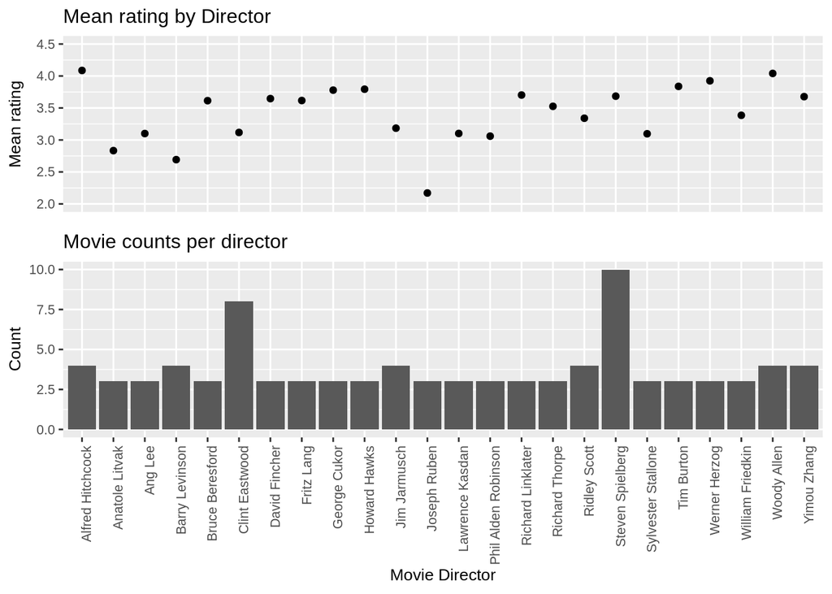

Figure 9: Mean rating by director. Top graphic represents mean rating per director, while bottom graphic represents the movie count per director.

# Task 2 - Learn recommender systems using binary and non-binary information

## Modeling approaches

This section is destined to present a brief description of the modeling approaches applied with respective demonstration for a set of critics. In this particular case, we choose to work with a small data set composed by 6 critics and 10 movies that can be consulted in Table 3. The first 5 critics were used to train the models and the last one to make the predictions. To do so, binary and non-binary data were taken into account (Figure 10 and 11) and three different modeling approaches were applied: popularity, association rules and collaborative filtering.

Table 3: Data set used for modeling approaches demonstration

|  | Critics | items |
| --- | --- | --- |
| [1] | Brian Orndorf | {418,433,443,458,488,528,564,582,610} |
| [2] | Dustin Putman | {418,443,458,488,564,610,611} |
| [3] | Emanuel Levy | {418,458,528,610} |
| [4] | Eric D. Snider | {418,433,443,458,488,528,564,610,611} |
| [5] | Michael Dequina | {433,443,458,564} |
| [6] | Scott Weinberg | {443,458} |

```
##                 418 433 443 458 488 528 564 582 610 611
## Brian Orndorf     1   1   1   1   1   1   1   1   1   0
## Dustin Putman     1   0   1   1   1   0   1   0   1   1
## Emanuel Levy      1   0   0   1   0   1   0   0   1   0
## Eric D. Snider    1   1   1   1   1   1   1   0   1   1
## Michael Dequina   0   1   1   1   0   0   1   0   0   0
## Scott Weinberg    0   0   1   1   0   0   0   0   0   0
```

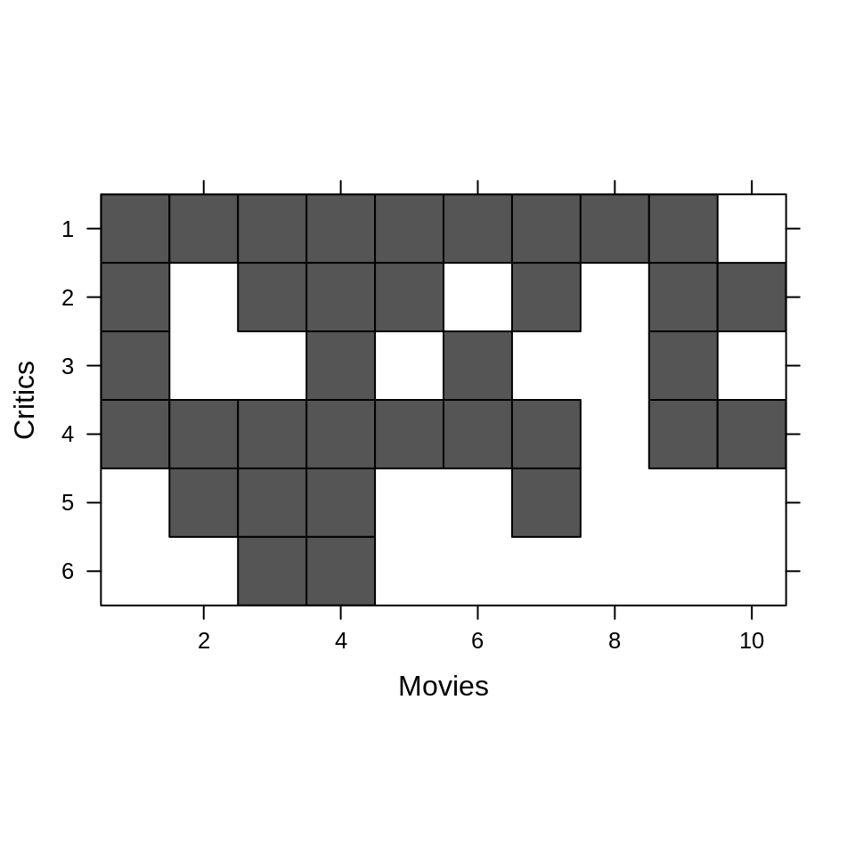

Figure 10: Heatmap representing binary data

```
## 6 x 10 sparse Matrix of class "dgCMatrix"
##
## Brian Orndorf   3.1 0.5 0.6 4.7 3.1 3.3 3.9 3.9 3.6 .
## Dustin Putman   2.5 .   1.2 2.5 2.5 .   2.5 .   1.2 2.5
## Emanuel Levy    3.3 .   .   3.9 .   4.2 .   .   3.1 .
## Eric D. Snider  4.2 3.3 2.5 4.2 3.6 4.2 3.9 .   3.1 4.7
## Michael Dequina .   5.5 2.5 3.8 .   .   2.5 .   .   .
## Scott Weinberg  .   .   3.0 4.0 .   .   .   .   .   .
```

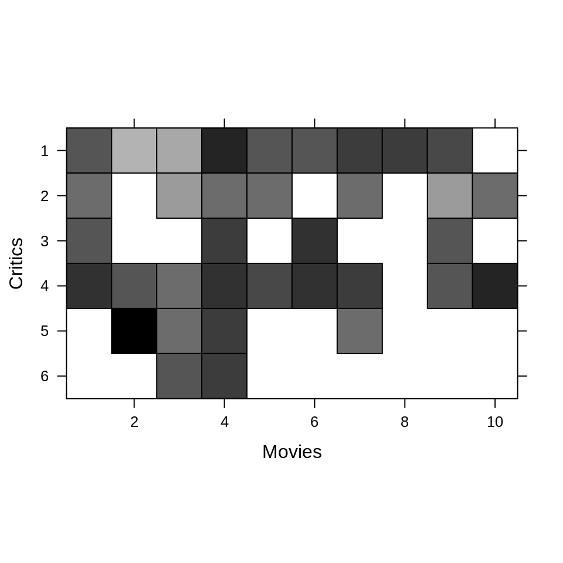

Figure 11: Heatmap representing non-binary data considering each crtic’s rating to each movie.

### Popularity

Popularity based recommendation-systems are the most simple, non-personalized models which generate recommendations solely on the popularity of items, i. e., the number of users who have the item in their profile. These models are predominantly applied when there is not much information available about a certain user’s preference and hence a popular item among many users will probably also appeal to a generic user. However, popular items may be widely liked and hence their ratings carry little useful information for constructing the user’s profile. Besides, these recommender systems do not take in consideration any information of the users likes and dislikes what can harm recommendation quality. Even so, their performance is usually satisfactory.

The movies in the set are displayed below in decreasing order of popularity.

```
## [[1]]
##  [1] "458" "418" "443" "564" "610" "433" "488" "528" "611" "582"
```

However, since Scott Weinberg had already seen the movies indexed by 443 and 458 and attending to the three most popular, only the following could/would be recommended.

```
## $`Scott Weinberg`
## [1] "418" "564" "610"
```

### Association Rules

Association rules have been widely used in many fields to extract significant associations between variables in large databases, including in market basket analysis and recommendation systems. The ultimate goal of association rules algorithms is to mimic human capability of extracting abstract associations from uncategorized data. In the context of recommender systems, user’s behavior is used to infer valuable connections that allow the development of personalized recommendations of items, such as, users that like this item will probably also like this item. One disadvantage of this approach is that a large number of rules are produced in every application and most of the rules do not present useful information, i.e., they are redundant or too obvious. Moreover, although there are some measures of the rule’s interestingness, there is no way of discarding useless sets of rules but to individually infer it relevance on the domain’s optic. Although it presents usually good results, these aspects can difficult it application to certain tasks.

In the first place, 233 rules were obtained using a minimum support of 0.1 and minimum confidence of 0.8. After eliminating the rules that contained the already seen movies on the right hand side, the ones that lacked the already seen movies on the left hand side and also adjusting the support and confidence threshold for 0.8, a total of seven rules were obtained (Figure 12).

```
##     lhs          rhs   support confidence lift count
## [1] {443}     => {564} 0.8     1.0        1.25 4
## [2] {443,458} => {564} 0.8     1.0        1.25 4
## [3] {418,458} => {610} 0.8     1.0        1.25 4
## [4] {458,610} => {418} 0.8     1.0        1.25 4
## [5] {458}     => {564} 0.8     0.8        1.00 4
## [6] {458}     => {418} 0.8     0.8        1.00 4
## [7] {458}     => {610} 0.8     0.8        1.00 4
```

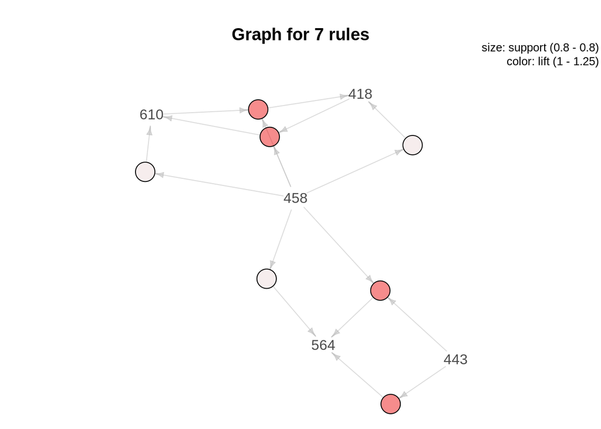

Figure 12: Plot of the final 7 rules selected.

From the analysis of the set of rules we can conclude with 100% confidence that Scott Weinberg, whom have seen movies indexed by 443 and 458, will probably also like the movie indexed by 564, according to rules number 1 and 2. Furthermore, we can also infer with 80% confidence that the user in cause will probably also like movies indexed by 418 and 610, supported by rules numbers 6 and 7, respectively. Hence, the movies to be recommended to Scott would be the ones represented by the ids 564,418 and 610.

### Collaborative Filtering

Finally, collaborative filtering approach rely on delivering recommendations to a certain active user based on the leverage knowledge of a community of similar users or items identical to the ones he had liked or seen in the past. Therefore, collaborative filtering models can be divided in two categories: user-based collaborative filtering (UBCF) or item-based collaborative filtering (IBCF). The first concept delivers recommendations to a certain user based on items that others users with similar tastes liked in the past, independently of the item’s content. The similarity between two users is determined by each behavior regarding item’s acquisition or rating, for binary or non-binary metrics respectively. That is to say, similar users have similar ratings/interest on the same item. On the other hand, IBCF recommendations are made based on the similarity among items which is given by the resemblance of the ratings/interest received from a given user. The combination of all users feedback is then used to cluster the items in similar sets. This way, the information provided by a particular user on a set of items is used to predict his interest on a similar unseen item. Cosine similarity, Pearson correlation coefficient and jaccard index are some of the similarity measures that can be use in this studies.

For the UBCF model using binary data the following similarity matrix was obtained when jaccard index was applied as similarity measure (Table 4).

Table 4: User based similiraty matrix using jaccard index and binary data.

|  | Brian Orndorf | Dustin Putman | Emanuel Levy | Eric D. Snider | Michael Dequina | Scott Weinberg |
| --- | --- | --- | --- | --- | --- | --- |
| Brian Orndorf | 0.0000000 | 0.6000000 | 0.4444444 | 0.8000000 | 0.4444444 | 0.2222222 |
| Dustin Putman | 0.6000000 | 0.0000000 | 0.3750000 | 0.7777778 | 0.3750000 | 0.2857143 |
| Emanuel Levy | 0.4444444 | 0.3750000 | 0.0000000 | 0.4444444 | 0.1428571 | 0.2000000 |
| Eric D. Snider | 0.8000000 | 0.7777778 | 0.4444444 | 0.0000000 | 0.4444444 | 0.2222222 |
| Michael Dequina | 0.4444444 | 0.3750000 | 0.1428571 | 0.4444444 | 0.0000000 | 0.5000000 |
| Scott Weinberg | 0.2222222 | 0.2857143 | 0.2000000 | 0.2222222 | 0.5000000 | 0.0000000 |

As one can observe, the two most similar users to Scott Weinberg are Michael Dequina and Dustin Putman. Hence, one can infer the movies to be recommended from the evaluation of the score values of each movie seen by Dustin and Michael but not by Scott.

The value of score for a given movie i can be calculated by the sum of the similarity between the target user and its neighbors times 1 or 0, weather the neighbor have seen the movie i or not, divided by the number of neighbors considered. That is to say, the score is influenced by the similarity between the user and its targets and also by the number of neighbors that has in fact watched the movies. Therefore, the top 3 movies to be recommended are the ones represented by the id 564, since it has been watched by both closest neighbors, 433, since Michael is the neighbor with higher similarity, and finally 418, although it has the same score as movies 488, 610 and 611.

For the IBCF model using binary data the following similarity matrix was obtained when jaccard index was applied as similarity measure (Table 5).

Table 5: Item bases similarity matrix using jaccard index and binary data.

|  | 418 | 433 | 443 | 458 | 488 | 528 | 564 | 582 | 610 | 611 |
| --- | --- | --- | --- | --- | --- | --- | --- | --- | --- | --- |
| 418 | 0.0000000 | 0.4000000 | 0.5000000 | 0.6666667 | 0.7500000 | 0.7500000 | 0.6000000 | 0.2500000 | 1.0000000 | 0.5000000 |
| 433 | 0.4000000 | 0.0000000 | 0.6000000 | 0.5000000 | 0.5000000 | 0.5000000 | 0.7500000 | 0.3333333 | 0.4000000 | 0.2500000 |
| 443 | 0.5000000 | 0.6000000 | 0.0000000 | 0.8333333 | 0.6000000 | 0.3333333 | 0.8000000 | 0.2000000 | 0.5000000 | 0.4000000 |
| 458 | 0.6666667 | 0.5000000 | 0.8333333 | 0.0000000 | 0.5000000 | 0.5000000 | 0.6666667 | 0.1666667 | 0.6666667 | 0.3333333 |
| 488 | 0.7500000 | 0.5000000 | 0.6000000 | 0.5000000 | 0.0000000 | 0.5000000 | 0.7500000 | 0.3333333 | 0.7500000 | 0.6666667 |
| 528 | 0.7500000 | 0.5000000 | 0.3333333 | 0.5000000 | 0.5000000 | 0.0000000 | 0.4000000 | 0.3333333 | 0.7500000 | 0.2500000 |
| 564 | 0.6000000 | 0.7500000 | 0.8000000 | 0.6666667 | 0.7500000 | 0.4000000 | 0.0000000 | 0.2500000 | 0.6000000 | 0.5000000 |
| 582 | 0.2500000 | 0.3333333 | 0.2000000 | 0.1666667 | 0.3333333 | 0.3333333 | 0.2500000 | 0.0000000 | 0.2500000 | 0.0000000 |
| 610 | 1.0000000 | 0.4000000 | 0.5000000 | 0.6666667 | 0.7500000 | 0.7500000 | 0.6000000 | 0.2500000 | 0.0000000 | 0.5000000 |
| 611 | 0.5000000 | 0.2500000 | 0.4000000 | 0.3333333 | 0.6666667 | 0.2500000 | 0.5000000 | 0.0000000 | 0.5000000 | 0.0000000 |

In this case, we have to take into account that Scott watched the movies indexed by 443 and 458. The 3 most similar films to these two are the movies represented by the ids 564, 418 and 610, which correspond to the ones to be recommended.

For the UBCF model using non binary data the following similarity matrix was obtained when cosine similarity was applied (Table 6).

Table 6: User based similarity matrix using cosine similarity and non-binary data.

|  | Brian Orndorf | Dustin Putman | Emanuel Levy | Eric D. Snider | Michael Dequina | Scott Weinberg |
| --- | --- | --- | --- | --- | --- | --- |
| Brian Orndorf | 0.0000000 | 0.9527176 | 0.9842229 | 0.9341904 | 0.6842406 | 0.8695390 |
| Dustin Putman | 0.9527176 | 0.0000000 | 0.9734945 | 0.9896579 | 0.9675448 | 0.9808571 |
| Emanuel Levy | 0.9842229 | 0.9734945 | 0.0000000 | 0.9953616 | 1.0000000 | 1.0000000 |
| Eric D. Snider | 0.9341904 | 0.9896579 | 0.9953616 | 0.0000000 | 0.9371795 | 0.9943246 |
| Michael Dequina | 0.6842406 | 0.9675448 | 1.0000000 | 0.9371795 | 0.0000000 | 0.9981036 |
| Scott Weinberg | 0.8695390 | 0.9808571 | 1.0000000 | 0.9943246 | 0.9981036 | 0.0000000 |

The two most similar users to Scott obtained by this method are Emanuel and Michael. We used the weighted method to estimate the ratings given by Scott to each film based on his closest neighbor’s ratings.

The predicted ratings can be consulted below.

```
## $`Scott Weinberg`
##      418      433      488      528      564      582      610      611
## 3.620692 3.235624 3.573556 3.783277 3.608600 3.698301 3.212532 3.759739
```

Based on the obtained ratings, we can infer that the top 3 movies to be recommended are the ones indexed by 528, 611 and 582 since they exhibit the highest values.

Similarly, for the IBCF model using non binary data the following similarity matrix was obtained when jaccard index cosine similarity was applied.

Table 7: Item based similarity matrix using cosine-similarity and non-binary data

|  | 418 | 433 | 443 | 458 | 488 | 528 | 564 | 582 | 610 | 611 |
| --- | --- | --- | --- | --- | --- | --- | --- | --- | --- | --- |
| 418 | 0.0000000 | 0.5773503 | 0.7500000 | 0.8944272 | 0.8660254 | 0.8660254 | 0.7500000 | 0.5000000 | 1.0000000 | 0.7071068 |
| 433 | 0.5773503 | 0.0000000 | 0.8660254 | 0.7745967 | 0.6666667 | 0.6666667 | 0.8660254 | 0.5773503 | 0.5773503 | 0.4082483 |
| 443 | 0.7500000 | 0.8660254 | 0.0000000 | 0.8944272 | 0.8660254 | 0.5773503 | 1.0000000 | 0.5000000 | 0.7500000 | 0.7071068 |
| 458 | 0.8944272 | 0.7745967 | 0.8944272 | 0.0000000 | 0.7745967 | 0.7745967 | 0.8944272 | 0.4472136 | 0.8944272 | 0.6324555 |
| 488 | 0.8660254 | 0.6666667 | 0.8660254 | 0.7745967 | 0.0000000 | 0.6666667 | 0.8660254 | 0.5773503 | 0.8660254 | 0.8164966 |
| 528 | 0.8660254 | 0.6666667 | 0.5773503 | 0.7745967 | 0.6666667 | 0.0000000 | 0.5773503 | 0.5773503 | 0.8660254 | 0.4082483 |
| 564 | 0.7500000 | 0.8660254 | 1.0000000 | 0.8944272 | 0.8660254 | 0.5773503 | 0.0000000 | 0.5000000 | 0.7500000 | 0.7071068 |
| 582 | 0.5000000 | 0.5773503 | 0.5000000 | 0.4472136 | 0.5773503 | 0.5773503 | 0.5000000 | 0.0000000 | 0.5000000 | 0.0000000 |
| 610 | 1.0000000 | 0.5773503 | 0.7500000 | 0.8944272 | 0.8660254 | 0.8660254 | 0.7500000 | 0.5000000 | 0.0000000 | 0.7071068 |
| 611 | 0.7071068 | 0.4082483 | 0.7071068 | 0.6324555 | 0.8164966 | 0.4082483 | 0.7071068 | 0.0000000 | 0.7071068 | 0.0000000 |

As previously performed, each film rating was esteemed by the weighted method, based on the respective similarity score to the movies previously viewed, and are available below. Accordingly, the top 3 movies for recommendation are 610, 564 and 433.

```
## $`Scott Weinberg`
##      418      433      488      528      564      582      610      611
## 3.348264 3.598939 3.493843 3.418228 3.620448 3.500000 3.729721 3.496773
```

In conclusion, different results are obtained when different methods are applied, varying also weather binary or non-binary data is used. Such outcome is not surprising attending that, as described above, each method has a very specific and unique procedure to estimate the best recommendations to a certain user.

Nowadays, collaborative filtering is considered to be the most popular and widely implemented technique in recommender systems. Another approach that is becoming very popular is the use of hybrid systems which result from the combination of different techniques, taking benefit from their advantages and minimizing their limitations. For instance, collaborative filtering method suffers from new-user problems since they do not have information available to make the recommendation. This does not limit content-bases approaches since recommendations are based on item’s description.

## Experimental setup and obtained results

We start our experimental setup by selecting only a smaller set of critics and movies in order to have a smaller number of observations. This is necessary in order to reduce the size of our data and facilitate further analysis. We selected only the critics with at least 14 reviews, which was the mean value of reviews per critic, and movies with at least 32 reviews, which was the mean number of reviews per movie. This means our *data* set has only the movies and critics with most interactions.

### Binary Data

We started by analyzing models constructed using binary information. Here, only the critic and the movie id are passed on to the matrix, which will contain information on whether or not a given critic has seen a particular movie. The previously described *data* set is first coerced into a binary rating matrix.

The heat-maps on figure 13 allows us to see that our data isn’t very sparse. In fact, if we check the top critics, we can see that most of them have seen most of the top movies.

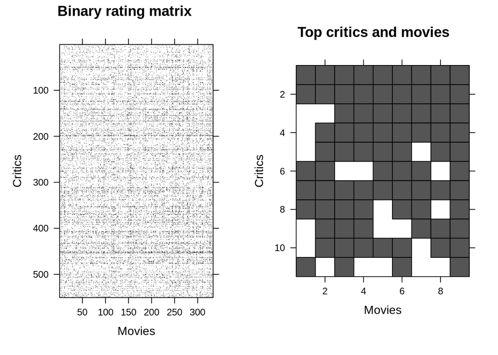

Figure 13: Heatmaps representing binary data considering which movies did each critic sa0.

In order to evaluate the different recommender algorithms, it is necessary to have a training set and a testing set. To obtain this sets from our data, we followed the protocol described in the *recommenderlab* package documentation. We used the split method, which randomly assigns a proportion to the test set and to the training set. We set this proportion at 80% train, and 20% test. The split method also generates a unknown and known sets, which are used for the evaluation of the resulting models. The unknown set represents a set where items are withheld from the profile of a given user, and the evaluation is based on how well the predicted results match the withheld value, which is saved in the known set.

Our goal is to compare different recommender systems, but each method has different parameters that can greatly influence their performance.In order to get the best comparison possible, we started by evaluating the performance of each method under different parameters. The set of parameters that presented the best results was used for the final comparison. The evaluation method selected was 10-fold cross-validation, with all but one evaluation, this means the algorithm is given only one randomly chosen item for the test user, and it is evaluated by how well it is able to predict the withheld item. This is measured by precision (quality of each recommendation) and recall (ratio of relevant items guessed). This scheme was applied for the top 1, 2 and 5 recommendations.

For UBCF method, five different sets of parameters were tested:

1. *Standard UBCF*: according to the *recommender* package *registry*, the UBCF parameters as default are Jaccard similarity method, nearest neighbors (nn) as 25, weighted as true, and sample as false.
2. *Cosine UBCF*: here we changed the similarity method from jaccard to cosine.
3. *Unweighted UBCF*: here we set weighted as false.
4. *nn 5 UBCF*: here the nn was set as 5, one fifth of the default value.
5. *nn 50 UBCF*: here the nn was set as 50, twice the default value.

The results in figure 14 show that UBCF with nn = 5 has the worse results, and that the remaining sets of parameters seem to have similar performances. However, the nn = 50 has slightly better results , and thus this set of parameters was selected as the best UBCF.

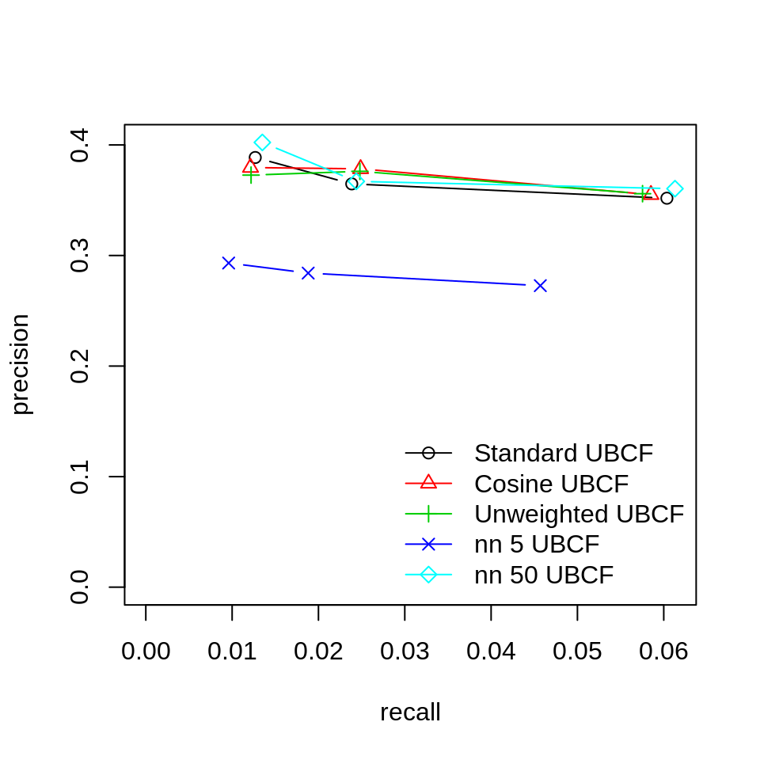

Figure 14: Precision and recall results for the evaluation of UBCF models under five different sets of parameters, for top 1,2 and 5 recommendation

For IBCF method, seven different sets of parameters were tested:

1. *Standard IBCF*: according to the *recommender* package *registry*, the IBCF parameters as default are Jaccard similarity method, nearest neighbors (k) as 30, the similarity matrix normalization is set as false, and alpha is set as 0.5.
2. *Cosine IBCF*: here we changed the similarity method from jaccard to cosine.
3. *normalized IBCF*: here we set we set similarity matrix normalization as true.
4. *alpha 0.25 IBCF*: here the alpha value was set to 0.25, half the default value.
5. *alpha 1 IBCF*: here the alpha value was set to 1, twice the default value.
6. *k 10 IBCF*: here the k was set as 10, one third of the default value.
7. *k 60 IBCF*: here the k was set as 60, twice the default value.

The results in figure 15 show that similarly to what occurred in UBCF, the best performing sets have very similar values. Yet from here, we decided to select cosine similarity as the best set of parameters.

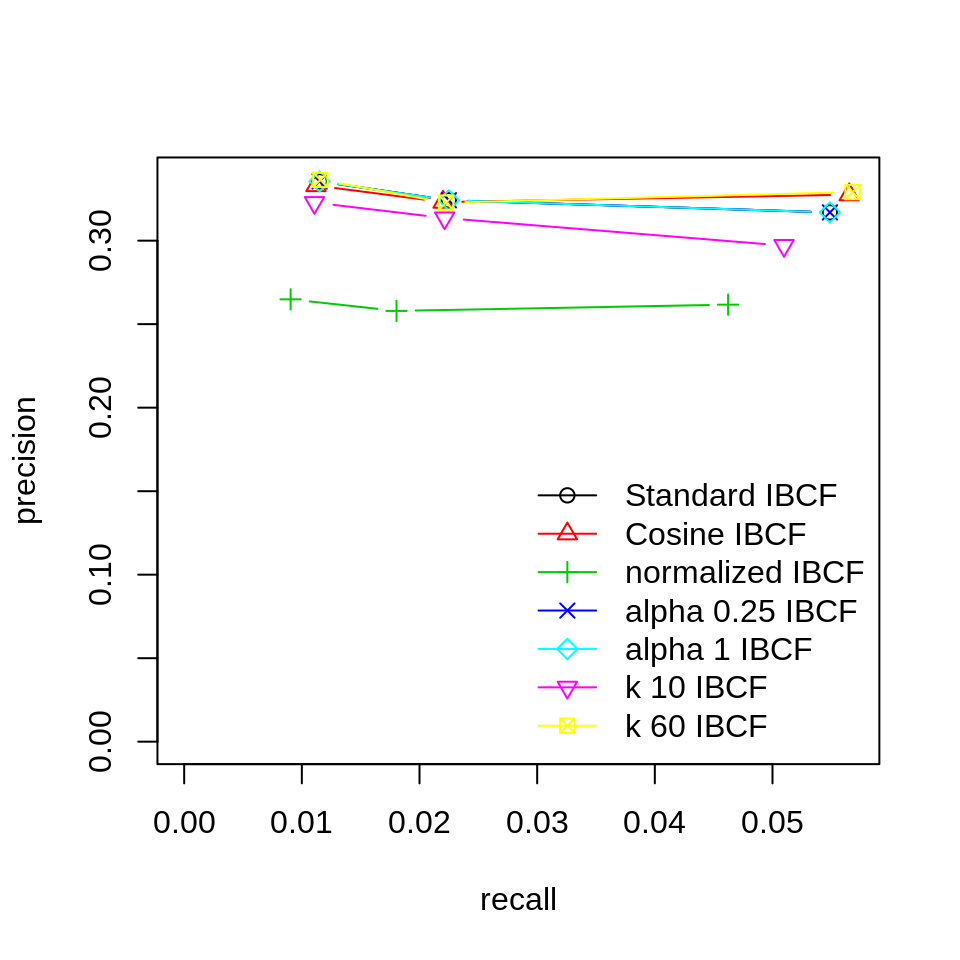

Figure 15: Precision and recall results for the evaluation of IBCF models under seven different sets of parameters, for top 1,2 and 5 recommendation

For AR method, five different sets of parameters were tested. Unlike for other methods, for the standard AR method which according to the *recommender* package *registry* as the default values of confidence and support as respectively 0.8 and 0.1, *calcPredictionAccuracy* is not able to calculate the precision value. As so, this set of parameters was not used in this evaluation.

1. *AR c0.1/s0.1*: with default support and confidence set as 0.1.
2. *AR c0.5/s0.1*: with default support and confidence set as 0.5.
3. *AR c0.1/s0.05*: with default confidence and support set as 0.05.
4. *AR c0.1/s0.025*: with default confidence and support set as 0.025.
5. *AR c0.5/s0.05*: with confidence at 0.5 and support set as 0.05.

The results in figure 16 show that support is the determining factor, while no changes are observed for the same support but with different confidence levels. As such, we selected the confidence 0.5 and support 0.05 as the best set of parameters. We chose confidence 0.5 over 0.1 because they present the same results, but with confidence 0.5 we have less rules, and thus it is more efficient. We choose this one over the support 0.1 because it has a more stable performance.

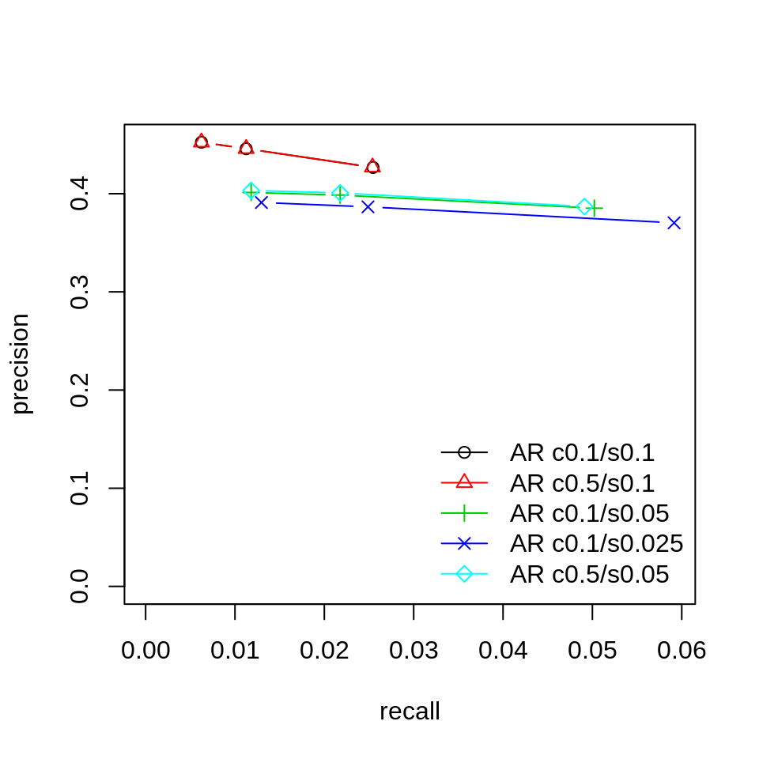

Figure 16: Precision and recall results for the evaluation of AR models under five different sets of parameters, for top 1,2 and 5 recommendation

The Popular method does not have any available parameters, thus this first step of evaluation was not performed.

With the previously determined best set of parameters, each method was once again evaluated, but this time against each other. The results in figure 17 show that UBCF has the best performance for our data set.

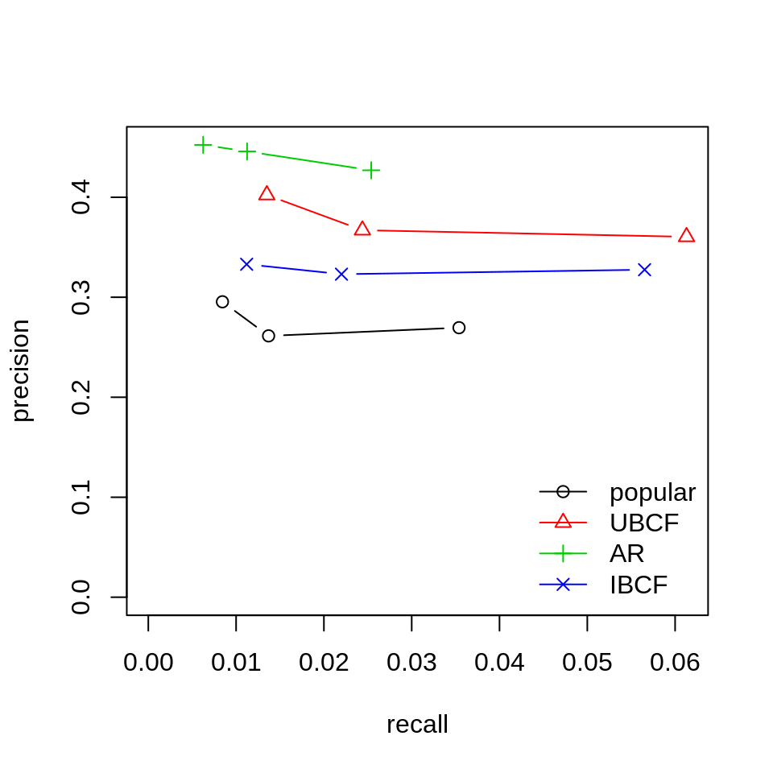

Figure 17: Precision and recall results for the evaluation of all tested methods under their best performing set of parameters, for top 1,2 and 5 recommendation.

In order to validate the results obtained above, manual evaluation was also performed. We started by constructing models with the *Recommender* function, with the previously selected parameters and the training set obtained from the split method. Then, predictions were obtained using the *predict* function, with the constructed models and the know set obtained in the split method. This was repeated for top 1, 2 and 5 recommendations.The results on figure 18 are in agreement with the ones above.

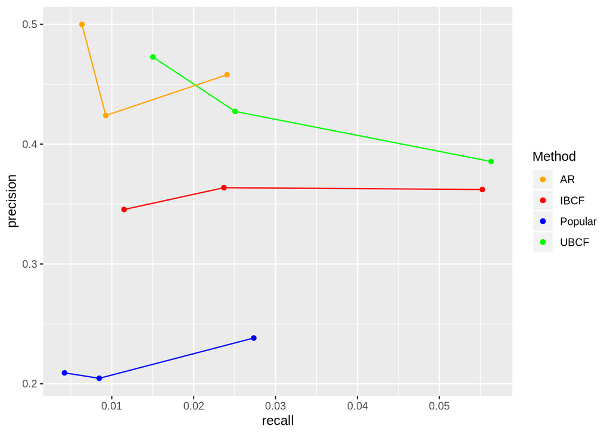

Figure 18: Precision and recall results for the evaluation of all tested methods under their best performing set of parameters for top 1,2 and 5 recommendation.

### Non-binary

#### Rating

For non-binary data, we also select only a smaller set of critics and movies as described above. The difference with in this non-binary approach is that besides the critic and the movie id, the ratings provided by the critics are also passed on to the matrix, which in this case is a real rating matrix. This will provide not only information on whether or not a critic has seen a given movie, but also how much he enjoyed it by the rating he provided. The split method was once again used to randomly assign a proportion to the test set and to the training set, and also generate a unknown and known sets.

To assess whether or not it is necessary to normalize our rating data, we constructed the heat-maps on figure 19. Normalization is important because users which have all their ratings either too high or too low might induce bias. The heat-maps represent the real rating matrix for the top critics and movies, with real ratings, and normalized. We can see that there aren’t any particular rows (critics) or columns (movies) that are too dark, or two light, thus normalization doesn’t seem to be necessary for our data.

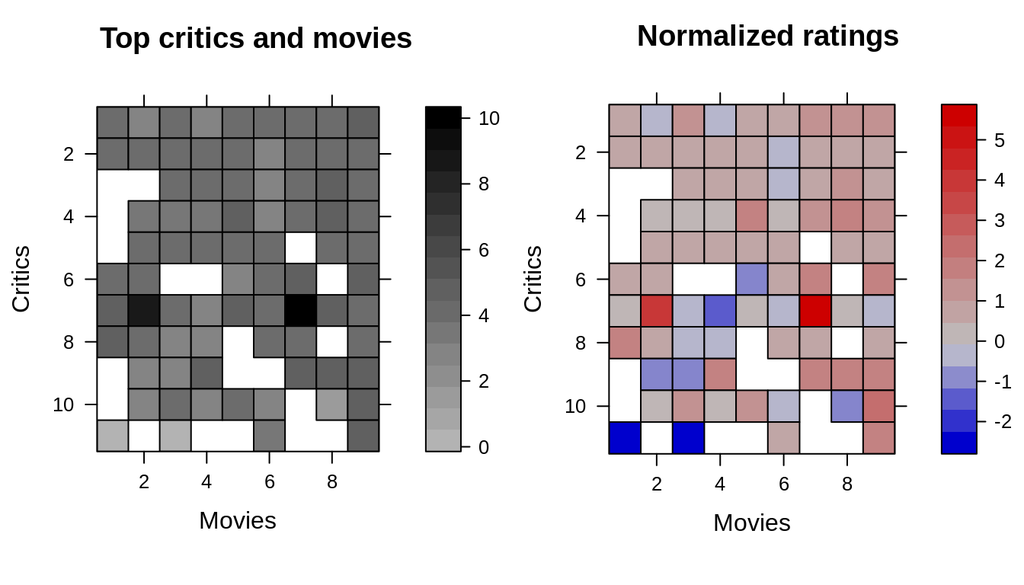

Figure 19: Standard and normalized heatmaps for top movies and critics in non-binary rating matrix

We started again by evaluating the performance of each method under different parameters and selecting set of parameters that presented the best results. The evaluation method is similar but with a difference. In this case, instead of giving a top-x recommendation, the goal is to predict the rating a given user would give to a specific item. So in the case, the evaluation is based on three error measures: root-mean-square error (RMSE), mean squared error (MSE) and mean absolute error (MAE).

For UBCF method, five different sets of parameters were tested:

1. *Standard UBCF*: according to the *recommender* package *registry*, the UBCF parameters as default are Cosine similarity method, nearest neighbors (nn) as 25, normalize as “center”, and sample as false.
2. *Jaccard UBCF*: here we changed the similarity method from cosine to jaccard.
3. **Z-score UBCF_**: here we set normalization with z-score.
4. *nn 5 UBCF*: here the nn was set as 5, one fifth of the default value.
5. *nn 50 UBCF*: here the nn was set as 50, twice the default value.

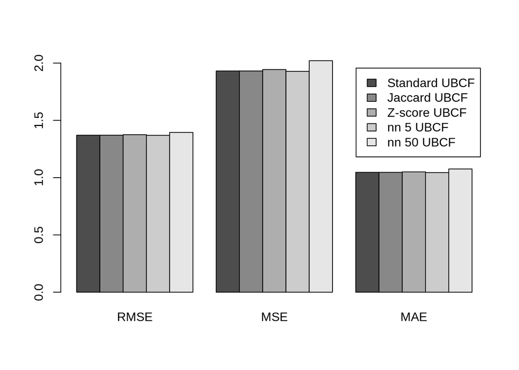

Figure 20: RMSE, MSE and MAE errors results for the evaluation of UBCF models under five different sets of parameters, for top 1,2 and 5 recommendation

1. *Standard IBCF*: according to the *recommender* package *registry*, the IBCF parameters as default are Cosine similarity method, nearest neighbors (k) as 30, the similarity matrix normalization is set as center, and alpha is set as 0.5.
2. *Jaccard IBCF*: here we changed the similarity method from cosine to jaccard.
3. *alpha 0.25 IBCF*: here the alpha value was set to 0.25, half the default value.
4. *alpha 1 IBCF*: here the alpha value was set to 1, twice the default value.
5. *k 10 IBCF*: here the k was set as 10, one third of the default value.
6. *k 60 IBCF*: here the k was set as 60, twice the default value.

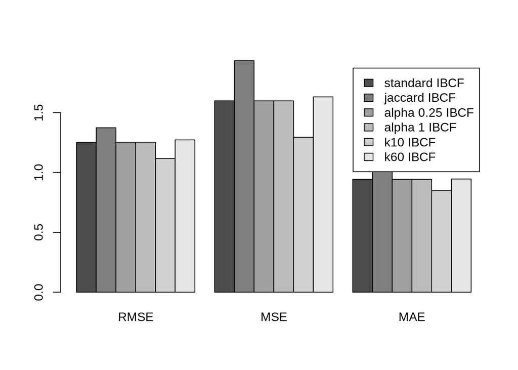

For POP method, unlike for the binary setup, two different sets of parameters were tested:

1. *Standard IBCF*: according to the *recommender* package *registry*, the Popular parameters as default normalize is set as center.
2. *Z-score IBCF*: here we changed the normalize parameter from center to z-score.

The results in figure 22 show that both have equal values of all error measures, and as such, the standard set was chosen for further analysis.

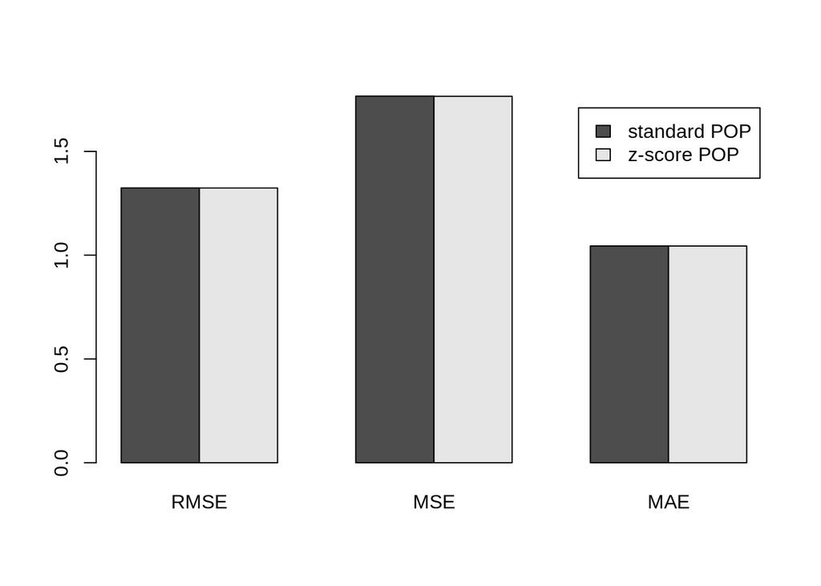

Figure 22: RMSE, MSE and MAE errors results for the evaluation of POP models under two different normalization conditions

Since AR doesn’t allow the input of ratings, this method is not used for non-binary data.The comparison of the remaining models is shown on figure 23 where we can observe that IBCF method presents the lowest values of error.

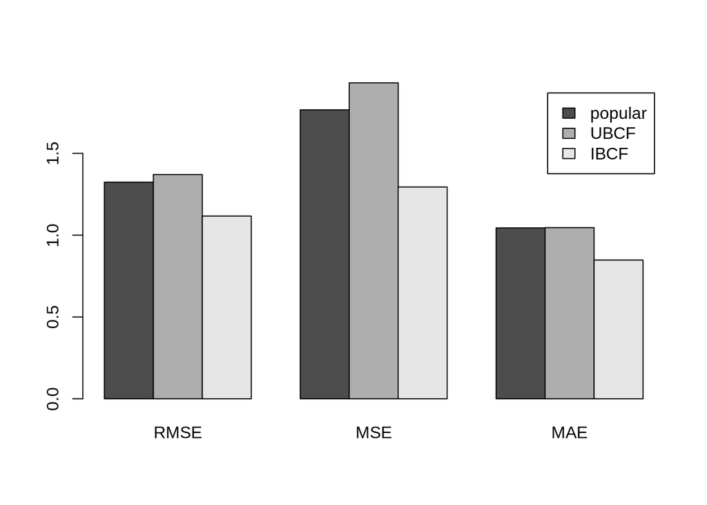

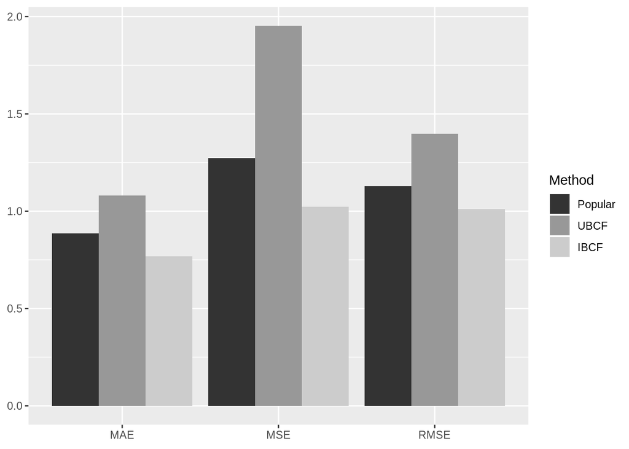

Figure 24: RMSE, MSE and MAE errors results for the evaluation of all tested methods under their best performing set of parameters.

#### Top-N

For UBCF method, five different sets of parameters were tested:

1. *Standard UBCF*: according to the *recommender* package *registry*, the UBCF parameters as default are Cosine similarity method, nearest neighbors (nn) as 25, normalize as “center”, and sample as false.
2. *Jaccard UBCF*: here we changed the similarity method from cosine to jaccard.
3. *Z-score UBCF*: here we set normalization with z-score.
4. *nn 5 UBCF*: here the nn was set as 5, one fifth of the default value.
5. *nn 50 UBCF*: here the nn was set as 50, twice the default value.

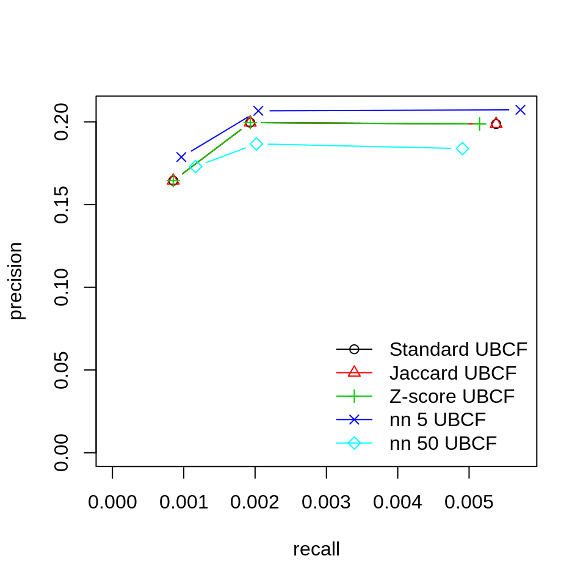

Figure 25: Precision and recall results for the evaluation of UBCF models under five different sets of parameters, for top 1,2 and 5 recommendation

1. *Standard IBCF*: according to the *recommender* package *registry*, the IBCF parameters as default are Cosine similarity method, nearest neighbors (k) as 30, the similarity matrix normalization is set as center, and alpha is set as 0.5.
2. *Jaccard IBCF*: here we changed the similarity method from cosine to jaccard.
3. *alpha 0.25 IBCF*: here the alpha value was set to 0.25, half the default value.
4. *alpha 1 IBCF*: here the alpha value was set to 1, twice the default value.
5. *k 10 IBCF*: here the k was set as 10, one third of the default value.
6. *k 60 IBCF*: here the k was set as 60, twice the default value.

The results on figure 26 show that the best performance is with k = 60.

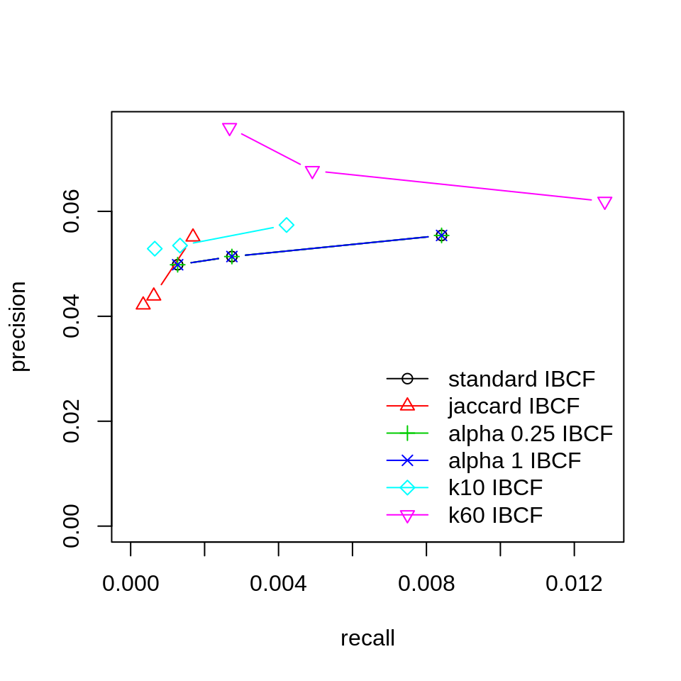

Figure 26: Precision and recall results for the evaluation of IBCF models under six different sets of parameters, for top 1,2 and 5 recommendation

For POP method, unlike for the binary setup, two different sets of parameters were tested:

1. *Standard IBCF*: according to the *recommender* package *registry*, the Popular parameters as default normalize is set as center.
2. *Z-score IBCF*: here we changed the normalize parameter from center to z-score.

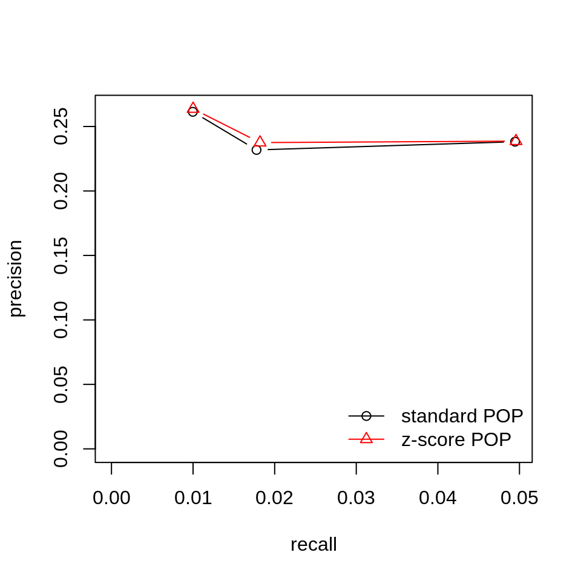

Figure 27: Precision and recall results for the evaluation of Popular models under two different sets of parameters, for top 1,2 and 5 recommendation

When evaluating the three methods under its best performing techniques, we can see that surprisingly, popular shows the best results (figure 28).

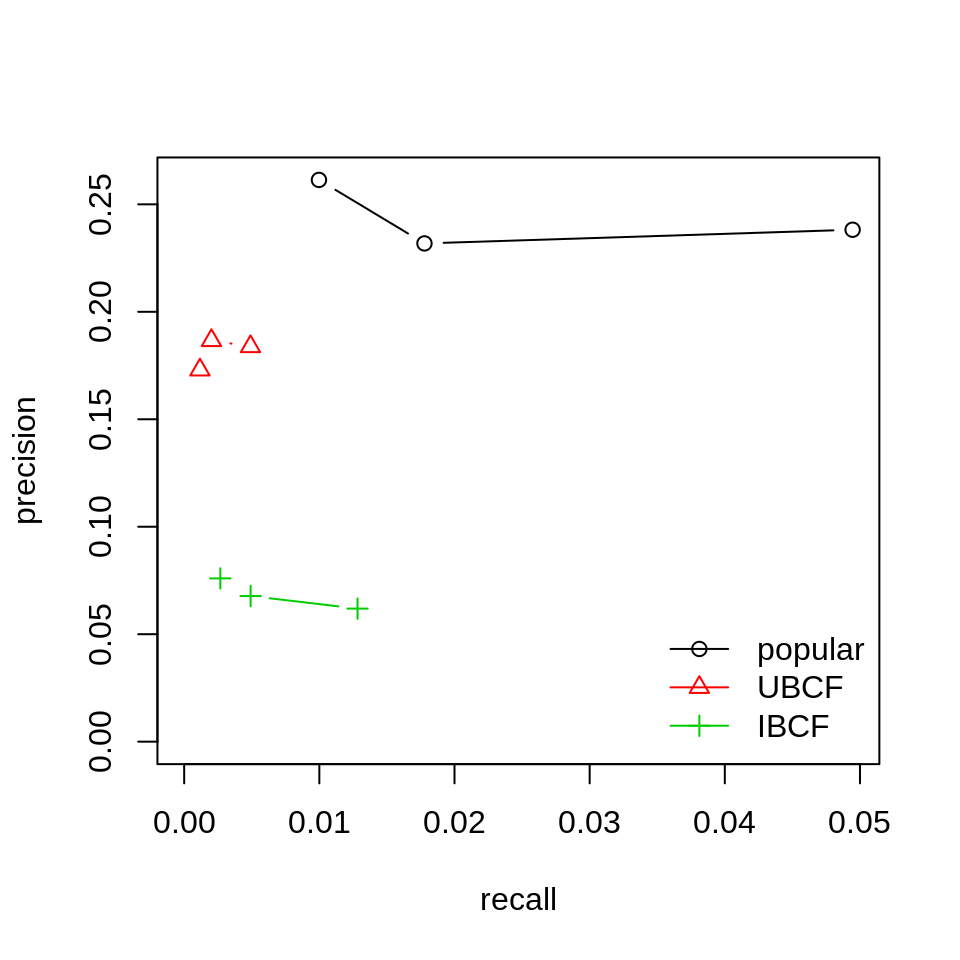

Figure 28: Precision and recall results for the evaluation of all tested methods under their best performing set of parameters

Our “manual” analysis through **calcPredictionAccuracy** (figure 29) confirms the results obtained from the k-fold validation.

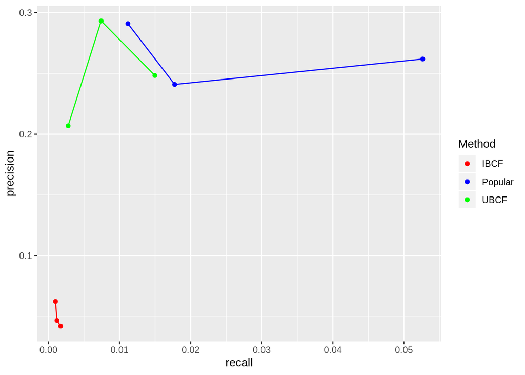

Figure 29: Validation of precision and recall results for the evaluation of all tested methods under their best performing set of parameters for top 1,2 and 5 recommendation using **calcPredictionAccuracy** method.

# Task 3 - Context-aware recommendation

## Movie Genre

From the exploratory analysis by gender (figure 8), the Romance genre seems to be a good candidate to a good influencer since it is a specific gender, has a reasonable number of films and his ratings are above the average.

We start to analyse the binary data with UBCF model.

For UBCF method, two different sets of parameters were tested:

1. *Cosine UBCF:* here we changed the similarity method from jaccard to cosine.
2. *nn 50 UBCF:* here the nn was set as 50, twice the default value.

Results on figure 30 show that nn50 protocol has almost the same performance than cosine protocol in UBCF model. Through this graph it is possible to compare the results previously obtained present on figure 14, being possible to verify that the Romance genre negatively influences the UBCF model since the precision values for the cosine and nn50 parameters are slightly lower.

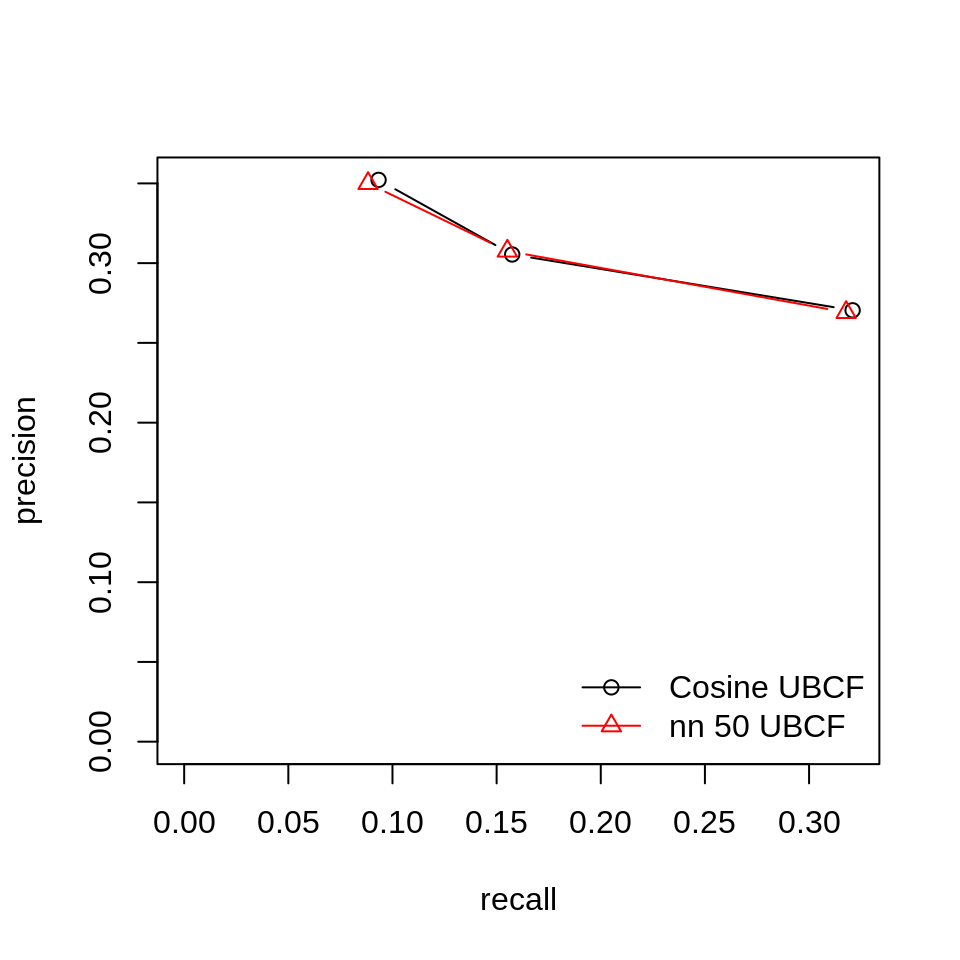

Figure 30: Precision and recall results for the UBCF model under two different sets of parameters

In order to validate the results obtained above, manual evaluation was also performed.

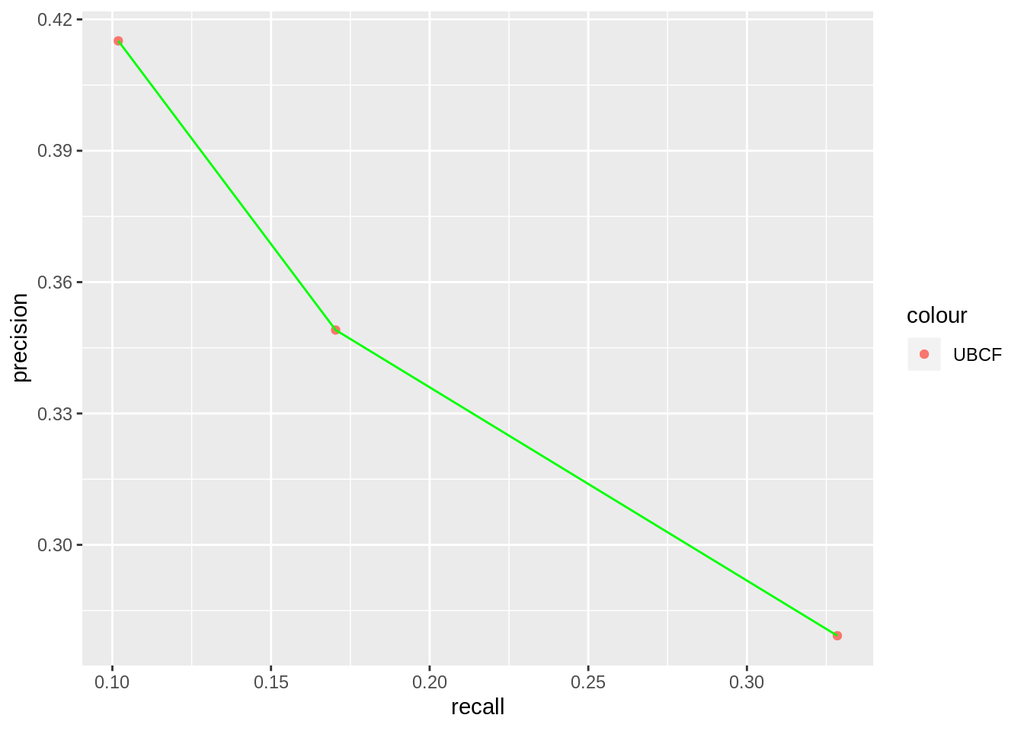

Figure 31: Precision and recall results for the evaluation of UBCF model

The results obtained and displayed in figure 31 are in agreement to the ones obtained on the first place. However, the quality prediction for the top 5 recommendation decreased significantly.